# Practical Machine Learning Course Project

Ross Gelber

February 10, 2017

## Loading and Cleaning the Data

There are a number of steps involved here in loading the data and getting it ready for analysis. After reading in the data, we remove columns where a large portion of the data is missing or are NAs. Then we split our traning data further into a traning set and a validation set. Then we look for variables that have either no variance or a very small variance and remove those. Then we remove variables that are unrelated to the modeling such as the individual’s name. Finally, we set the classe variable as a factor variable, so we can model that as our outcome.

```r
traindata <- fread("https://d396qusza40orc.cloudfront.net/predmachlearn/pml-training.csv")
testdata <- fread("https://d396qusza40orc.cloudfront.net/predmachlearn/pml-testing.csv")

nodata <- as.data.table(t(traindata[, lapply(.SD, function(x) sum(is.na(x) | x == "", na.rm = TRUE))]), keep.rownames = TRUE)
table(nodata$V1)
```

```
##
##     0 19216
##    60   100
```

```r
blankdata <- nodata[V1 != 0, rn]
traindata <- traindata[, setdiff(names(traindata), blankdata), with = FALSE]
testdata <- testdata[, setdiff(names(testdata), blankdata), with = FALSE]

traindata <- as.data.frame(traindata)
testdata <- as.data.frame(testdata)
traind <- createDataPartition(y = traindata$classe, p = 0.7, list = FALSE)
train <- traindata[traind,]
validate <- traindata[-traind,]

var <- nearZeroVar(traindata, saveMetrics = TRUE)
sum(var$zeroVar)
```

```
## [1] 0
```

```r
sum(var$nzv)
```

```
## [1] 1
```

```r
var <- var[order(-var$freqRatio),]
head(var)
```

```
##               freqRatio percentUnique zeroVar   nzv
## pitch_arm      87.25641   15.73234125   FALSE FALSE
## pitch_forearm  65.98305   14.85577413   FALSE FALSE
## roll_arm       52.33846   13.52563449   FALSE FALSE
## new_window     47.33005    0.01019264   FALSE  TRUE
## yaw_arm        33.02913   14.65701763   FALSE FALSE
## yaw_forearm    15.32283   10.14677403   FALSE FALSE
```

```r
train <- train[,setdiff(names(train),"new_window")]
validate <- validate[,setdiff(names(validate), "new_window")]
testdata <- testdata[,setdiff(names(testdata), "new_window")]

train <- train[, setdiff(names(train), c(grep("time|window", names(train), value = TRUE), "V1", "user_name"))]
validate <- validate[, setdiff(names(validate), c(grep("time|window", names(validate), value = TRUE), "V1", "user_name"))]
testdata <- testdata[, setdiff(names(testdata), c(grep("time|window", names(testdata), value = TRUE), "V1", "user_name"))]

train$classe <- as.factor(train$classe)
validate$classe <- as.factor(validate$classe)
```

# Modeling

We will start the modeling by creating a tree model to try to classify the data.

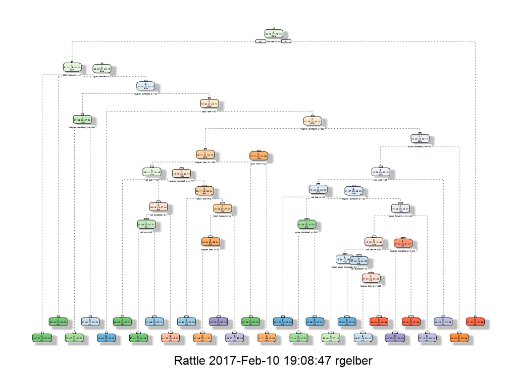

```r
tree <- rpart(classe ~ ., data = train, method = "class")
fancyRpartPlot(tree)
```

The tree model makes a lot of branches along the way to find the optimal classification. The first split it makes is on the variable rollbelt. This model splits observations where rollbelt >= 130 and rollbelt <130. The observations where rollbelt >=130 almost all fall into class E. After rollbeltm the second split is on the variable pitchforearm. It splits where pitchforearm < -34 and >= -34.

In order to validate this model, we can use or validate set and measure how accurate this classification model is on that data set.

```r
vTree <- predict(tree, validate, type = "class")
confusionMatrix(vTree, validate$classe)
```

```
## Confusion Matrix and Statistics
##
##           Reference
## Prediction    A    B    C    D    E
##          A 1540  153   14   92   60
##          B   67  810  148   58   62
##          C    5  102  767  153   72
##          D   50   58   55  627   83
##          E   12   16   42   34  805
##
## Overall Statistics
##
##                Accuracy : 0.773
##                  95% CI : (0.7621, 0.7836)
##     No Information Rate : 0.2845
##     P-Value [Acc > NIR] : < 2.2e-16
##
##                   Kappa : 0.7116
##  Mcnemar's Test P-Value : < 2.2e-16
##
## Statistics by Class:
##
##                      Class: A Class: B Class: C Class: D Class: E
## Sensitivity            0.9200   0.7112   0.7476   0.6504   0.7440
## Specificity            0.9242   0.9294   0.9317   0.9500   0.9783
## Pos Pred Value         0.8284   0.7074   0.6979   0.7182   0.8856
## Neg Pred Value         0.9667   0.9306   0.9459   0.9328   0.9443
## Prevalence             0.2845   0.1935   0.1743   0.1638   0.1839
## Detection Rate         0.2617   0.1376   0.1303   0.1065   0.1368
## Detection Prevalence   0.3159   0.1946   0.1867   0.1483   0.1545
## Balanced Accuracy      0.9221   0.8203   0.8396   0.8002   0.8612
```

The second type of model we are going to try is a Random Forest model

```r
controlRF <- trainControl(method = "cv", 5)
modelRF <- train(classe ~ ., data = train, method = "rf", trControl = controlRF, ntree = 250)
modelRF
```

```
## Random Forest
##
## 13737 samples
##    52 predictor
##     5 classes: 'A', 'B', 'C', 'D', 'E'
##
## No pre-processing
## Resampling: Cross-Validated (5 fold)
## Summary of sample sizes: 10988, 10990, 10990, 10989, 10991
## Resampling results across tuning parameters:
##
##   mtry  Accuracy   Kappa
##    2    0.9895900  0.9868307
##   27    0.9902453  0.9876596
##   52    0.9865322  0.9829632
##
## Accuracy was used to select the optimal model using  the largest value.
## The final value used for the model was mtry = 27.
```

```r
predictRF <- predict(modelRF, validate)
confusionMatrix(validate$classe, predictRF)
```

```
## Confusion Matrix and Statistics
##
##           Reference
## Prediction    A    B    C    D    E
##          A 1671    2    0    0    1
##          B    7 1129    3    0    0
##          C    0    5 1017    4    0
##          D    0    0   12  952    0
##          E    0    1    1    3 1077
##
## Overall Statistics
##
##                Accuracy : 0.9934
##                  95% CI : (0.991, 0.9953)
##     No Information Rate : 0.2851
##     P-Value [Acc > NIR] : < 2.2e-16
##
##                   Kappa : 0.9916
##  Mcnemar's Test P-Value : NA
##
## Statistics by Class:
##
##                      Class: A Class: B Class: C Class: D Class: E
## Sensitivity            0.9958   0.9930   0.9845   0.9927   0.9991
## Specificity            0.9993   0.9979   0.9981   0.9976   0.9990
## Pos Pred Value         0.9982   0.9912   0.9912   0.9876   0.9954
## Neg Pred Value         0.9983   0.9983   0.9967   0.9986   0.9998
## Prevalence             0.2851   0.1932   0.1755   0.1630   0.1832
## Detection Rate         0.2839   0.1918   0.1728   0.1618   0.1830
## Detection Prevalence   0.2845   0.1935   0.1743   0.1638   0.1839
## Balanced Accuracy      0.9976   0.9954   0.9913   0.9951   0.9990
```